# Exam 3 - take home

Vinay Vaida

2023-12-05

# 1. Maximum Likelihood Estimation

(10 pts)

The MLE for estimating the probability $\pi$ in a null model.

In the notes I have explained how the parameters for the logistic model (the $\beta$’s) are obtained by maximizing the log likelihood function. We are going to do the same but for a simpler model.

1. Write down the log likelihood for the null model, that is, the model where all probabilities are the same: $\pi_i = \pi =\frac{e^{\beta_0}}{1+e^{\beta_0}}$.

Follow the notes and replace the $\pi_i$’s by $\pi$. Answer:

L = Ans: a) The log likelihood for the null model, where all probabilities are the same ($\pi_i = \pi$), is given by:

$$L = \sum_{i=1}^{n} \log P(Y_i | \pi)$$

In this case, for binary outcomes (0 or 1), we can express $P(Y_i | \pi)$ as:

$$P(Y_i | \pi) = \pi^{Y_i} \cdot (1 -
\pi)^{1 - Y_i}$$

Substitute this expression into the log likelihood:

$$L = \sum_{i=1}^{n} \left[ Y_i \log(\pi)
+ (1 - Y_i) \log(1 - \pi) \right]$$

Now, since $\pi = \frac{e^{\beta_0}}{1+e^{\beta_0}}$, we can express $\log(\pi)$ and $\log(1 - \pi)$ in terms of $\beta_0$:

$$L = \sum_{i=1}^{n} \left[ Y_i
\log\left(\frac{e^{\beta_0}}{1+e^{\beta_0}}\right) + (1 - Y_i)
\log\left(1 - \frac{e^{\beta_0}}{1+e^{\beta_0}}\right) \right]$$

2. Find $\log L$, the log likelihood function and find it’s derivative with respect to $\pi$.

Find the MLE estimator for $\pi$ as the place where the maximum is achieved.

Hint: follow the notes. Answer:
$$\log L
= \sum_{i=1}^{n} \left[ Y_i \log(\pi) + (1 - Y_i) \log(1 - \pi) \right]$$

To find the derivative with respect to $\pi$, we take the derivative of the above expression:

$$\frac{d(\log L)}{d\pi} = \sum_{i=1}^{n}
\left[ \frac{Y_i}{\pi} - \frac{1 - Y_i}{1 - \pi} \right]$$

Setting this derivative to zero gives the MLE estimator for $\pi$:

$$\sum_{i=1}^{n} \left[ \frac{Y_i}{\pi} -
\frac{1 - Y_i}{1 - \pi} \right] = 0$$

If you are at a loss with this problem, ask for help.

# 2. Logistic Regression

(20 pts)

#### Titanic dataset:

Variables:

- PassengerId: Passenger ID
- Survived: Passenger Survival Indicator
- Pclass: Passenger Class
- Name: Name
- Sex: Sex
- Age: Age
- SibSp: Number of Siblings/Spouses Aboard
- Parch: Number of Parents/Children Aboard
- Ticket: Ticket Number
- Fare: Passenger Fare
- Cabin: Cabin
- Embarked: Port of Embarkation

```r
## Load the datasets
library(titanic)
str(titanic_train)
```

```
## 'data.frame':    891 obs. of  12 variables:
##  $ PassengerId: int  1 2 3 4 5 6 7 8 9 10 ...
##  $ Survived   : int  0 1 1 1 0 0 0 0 1 1 ...
##  $ Pclass     : int  3 1 3 1 3 3 1 3 3 2 ...
##  $ Name       : chr  "Braund, Mr. Owen Harris" "Cumings, Mrs. John Bradley (Florence Briggs Thayer)" "Heikkinen, Miss. Laina" "Futrelle, Mrs. Jacques Heath (Lily May Peel)" ...
##  $ Sex        : chr  "male" "female" "female" "female" ...
##  $ Age        : num  22 38 26 35 35 NA 54 2 27 14 ...
##  $ SibSp      : int  1 1 0 1 0 0 0 3 0 1 ...
##  $ Parch      : int  0 0 0 0 0 0 0 1 2 0 ...
##  $ Ticket     : chr  "A/5 21171" "PC 17599" "STON/O2. 3101282" "113803" ...
##  $ Fare       : num  7.25 71.28 7.92 53.1 8.05 ...
##  $ Cabin      : chr  "" "C85" "" "C123" ...
##  $ Embarked   : chr  "S" "C" "S" "S" ...
```

This library has 2 datasets, titanic_train and titanic_test. We will work with titanic_train

```r
sum(is.na(titanic_train))
```

```
## [1] 177
```

```r
mytitanic<-titanic_train[complete.cases(titanic_train),]
n<-dim(mytitanic)[1]
set.seed(1)
indx<-sample(1:n,.8*n)
titanic_mytrain<-mytitanic[indx,]
titanic_mytest<-mytitanic[-indx,]
```

Create a logistic model with no interactions. Be careful about the variables you include.

```r
titanicmod1<-glm(Survived ~ Pclass + Sex + Age + SibSp + Parch + Fare + Embarked,
                   data = titanic_mytrain,
                   family = "binomial")
summary(titanicmod1)
```

```
##
## Call:
## glm(formula = Survived ~ Pclass + Sex + Age + SibSp + Parch +
##     Fare + Embarked, family = "binomial", data = titanic_mytrain)
##
## Coefficients:
##               Estimate Std. Error z value Pr(>|z|)
## (Intercept)  18.240277 608.034234   0.030  0.97607
## Pclass       -1.304993   0.203151  -6.424 1.33e-10 ***
## Sexmale      -2.875194   0.260497 -11.037  < 2e-16 ***
## Age          -0.044061   0.009261  -4.758 1.96e-06 ***
## SibSp        -0.406014   0.156637  -2.592  0.00954 **
## Parch        -0.051546   0.143472  -0.359  0.71939
## Fare         -0.001061   0.004281  -0.248  0.80421
## EmbarkedC   -12.055925 608.033855  -0.020  0.98418
## EmbarkedQ   -12.825533 608.034093  -0.021  0.98317
## EmbarkedS   -12.573055 608.033831  -0.021  0.98350
## ---
## Signif. codes:  0 '***' 0.001 '**' 0.01 '*' 0.05 '.' 0.1 ' ' 1
##
## (Dispersion parameter for binomial family taken to be 1)
##
##     Null deviance: 769.86  on 570  degrees of freedom
## Residual deviance: 480.25  on 561  degrees of freedom
## AIC: 500.25
##
## Number of Fisher Scoring iterations: 13
```

1. (4pts) For this section, you need to know what the variables are.
- Interpret the coefficient for Pclass-
  - The coefficient for Pclass is -1.304993.
  - The interpretation is that for a one-unit increase in Pclass (moving from a lower class to a higher class), the log-odds of survival decrease by approximately 1.30.
  - The negative sign indicates that a higher passenger class is associated with a lower likelihood of survival.
- Interpret the coefficient for Sex -
  - The coefficient for Sexmale is -2.875194.
  - The interpretation is that being male (compared to being female) is associated with a decrease in the log-odds of survival by approximately 2.88.
  - The negative sign indicates that males are less likely to survive compared to females.
- Interpret the coefficient for Age -
  - The coefficient for Age is -0.044061.
  - The interpretation is that for a one-unit increase in age, the log-odds of survival decrease by approximately 0.044.
  - The negative sign indicates that older passengers are less likely to survive.

Visualization of fitted values vs variables in model.

```r
library(visreg)
```

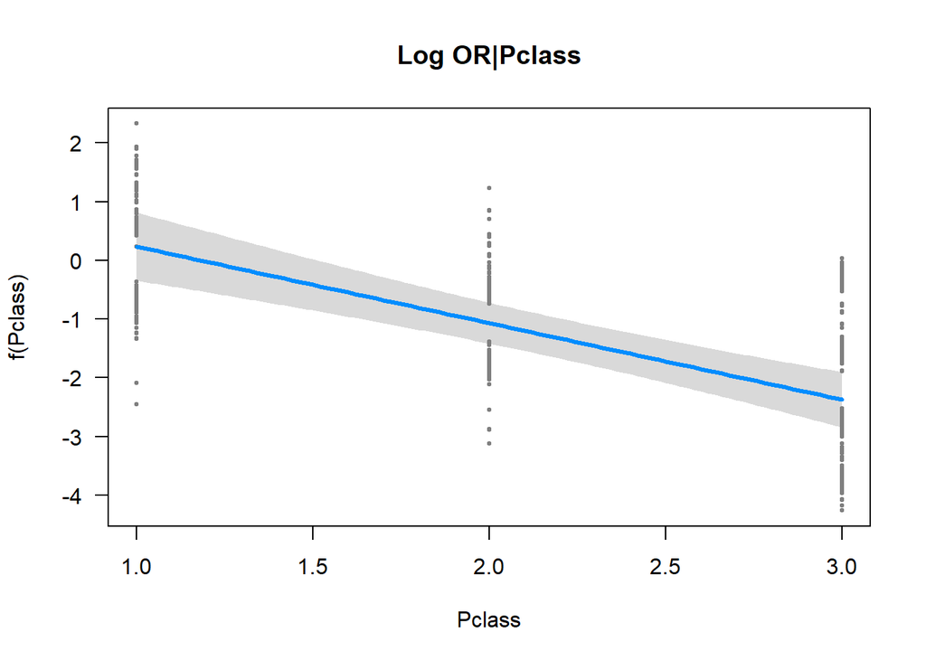

```r
visreg(titanicmod1, "Pclass", partial = TRUE,main="Log OR|Pclass") #plots the log odds ratios
```

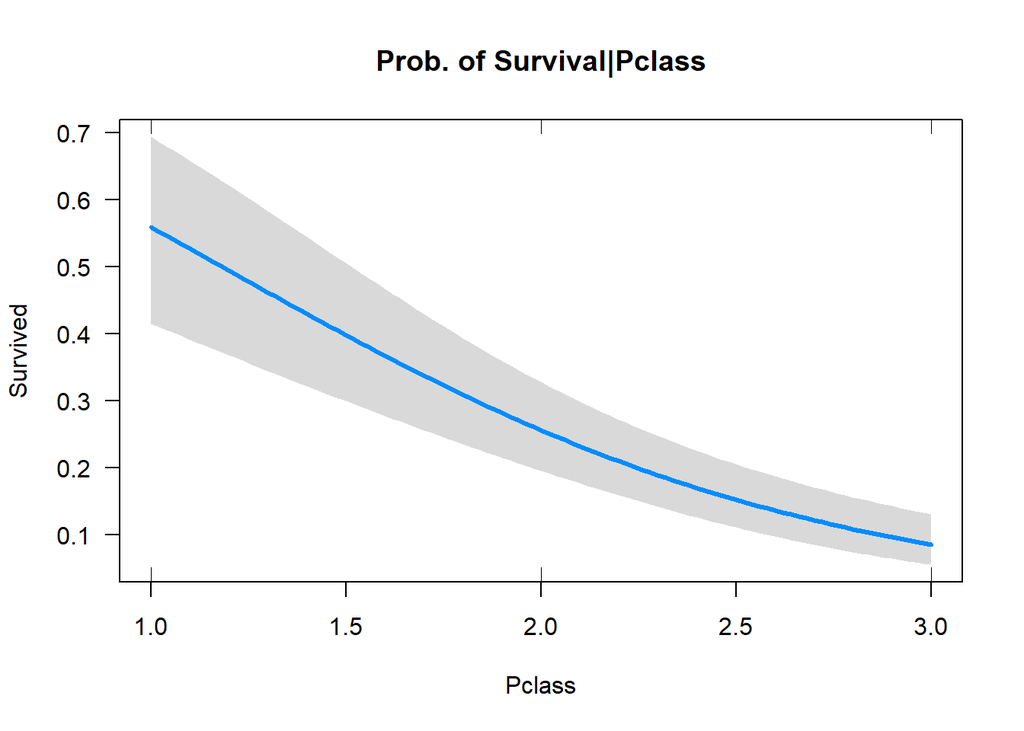

```r
visreg(titanicmod1, "Pclass", scale="response", partial=FALSE,main="Prob. of Survival|Pclass")  #plots probabilities
```

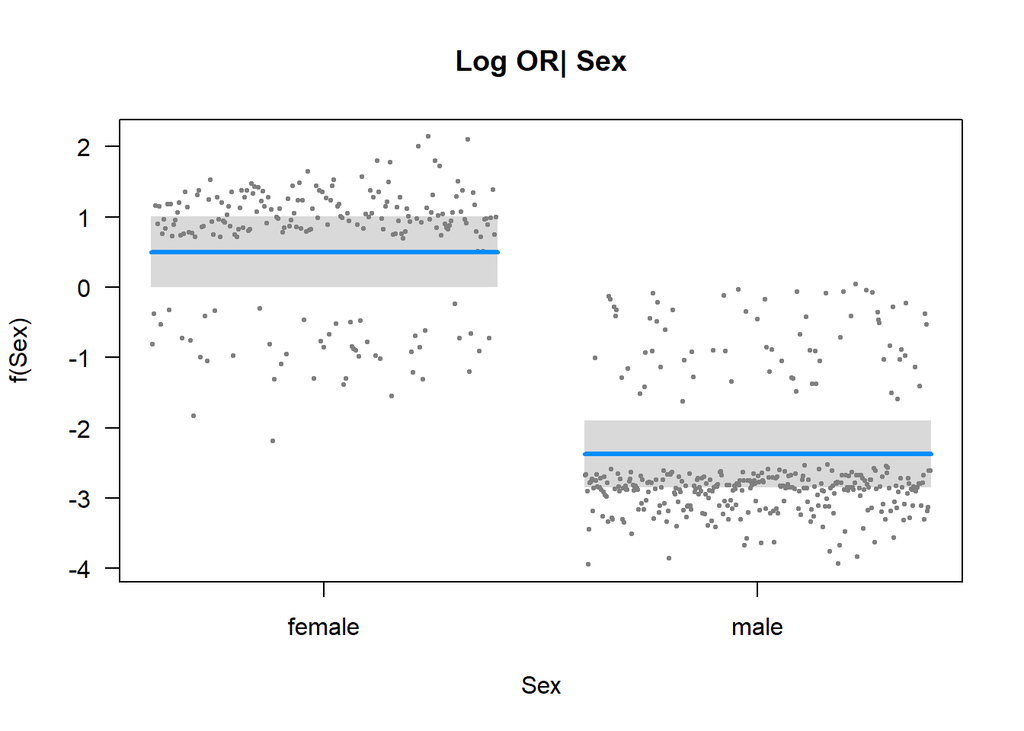

```r
visreg(titanicmod1, "Sex", partial = TRUE,main="Log OR| Sex")
```

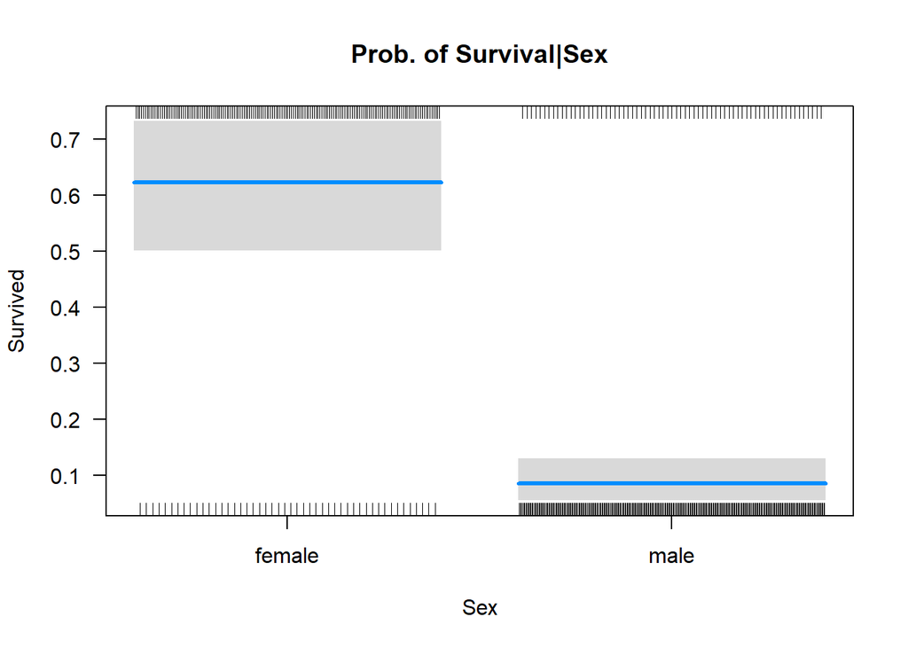

```r
visreg(titanicmod1, "Sex",scale="response", partial=FALSE,main="Prob. of Survival|Sex")  #plots probabilities
```

Some more visualizations of fitted vs Pclass:

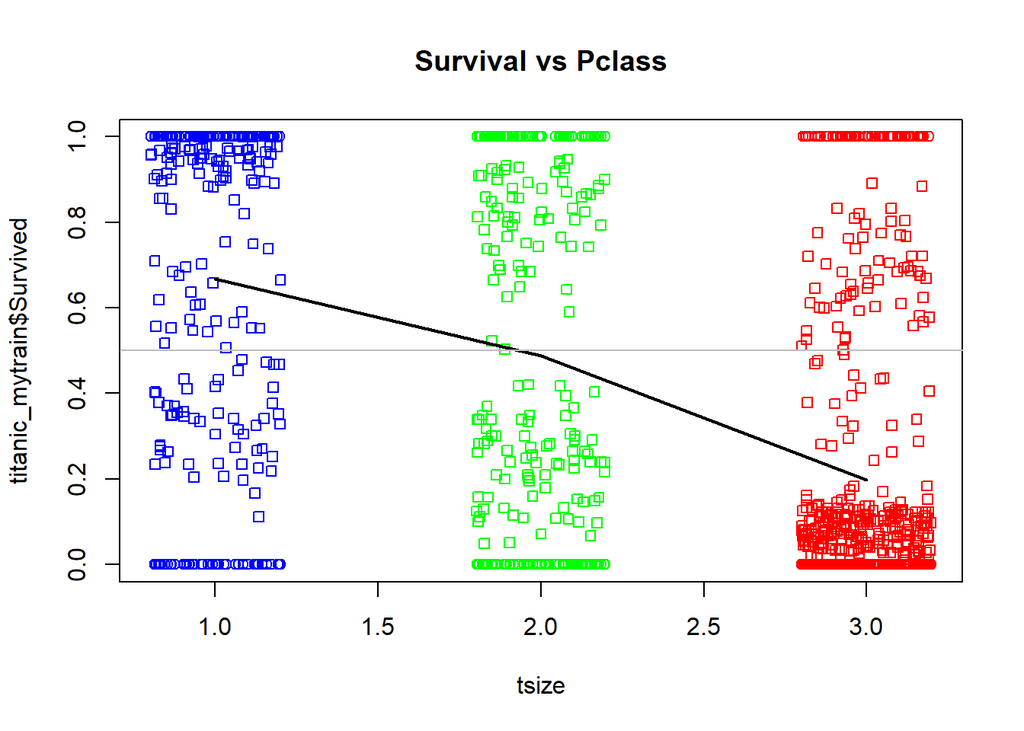

```r
x<-jitter(titanic_mytrain$Pclass)
plot(titanic_mytrain$Survived~x,col=c("blue","green","red")[titanic_mytrain$Pclass],xlab="tsize",main="Survival vs Pclass")
points(x,titanicmod1$fitted,col=c("blue","green","red")[titanic_mytrain$Pclass],pch=22)
#add fitted values curve
lines(lowess(titanic_mytrain$Pclass,titanicmod1$fitted),col="black",lwd=2)
#look at a threshold of .5
abline(h=.5,col='grey')
```

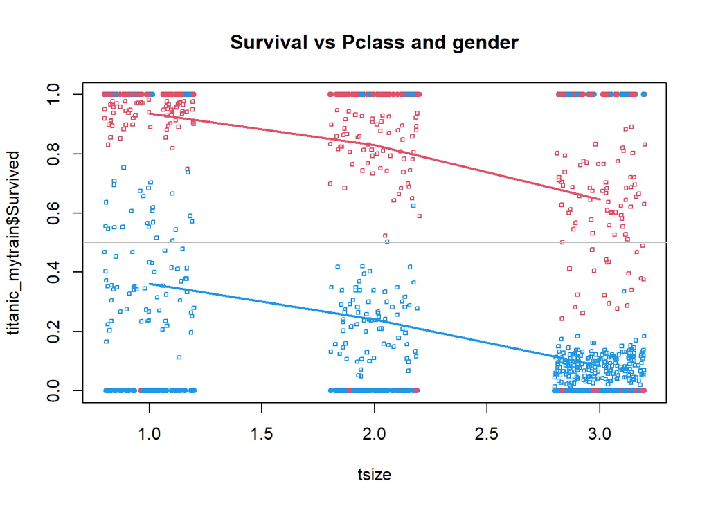

```r
x<-jitter(titanic_mytrain$Pclass)
scol<-ifelse(titanic_mytrain$Sex=="female",2,4)
plot(titanic_mytrain$Survived~x,col=scol,xlab="tsize",
     pch=19,cex=.7,main="Survival vs Pclass and gender")
points(x,titanicmod1$fitted,col=scol,pch=22,cex=.5)
#add fitted values curve
lines(lowess(titanic_mytrain$Pclass[titanic_mytrain$Sex=="female"],titanicmod1$fitted[titanic_mytrain$Sex=="female"]),col=2,lwd=2,cex=.5)
lines(lowess(titanic_mytrain$Pclass[titanic_mytrain$Sex=="male"],titanicmod1$fitted[titanic_mytrain$Sex=="male"]),col=4,lwd=2,cex=.5)
#look at a threshold of .5
abline(h=.5,col='grey')
```

Same thing with ggplot

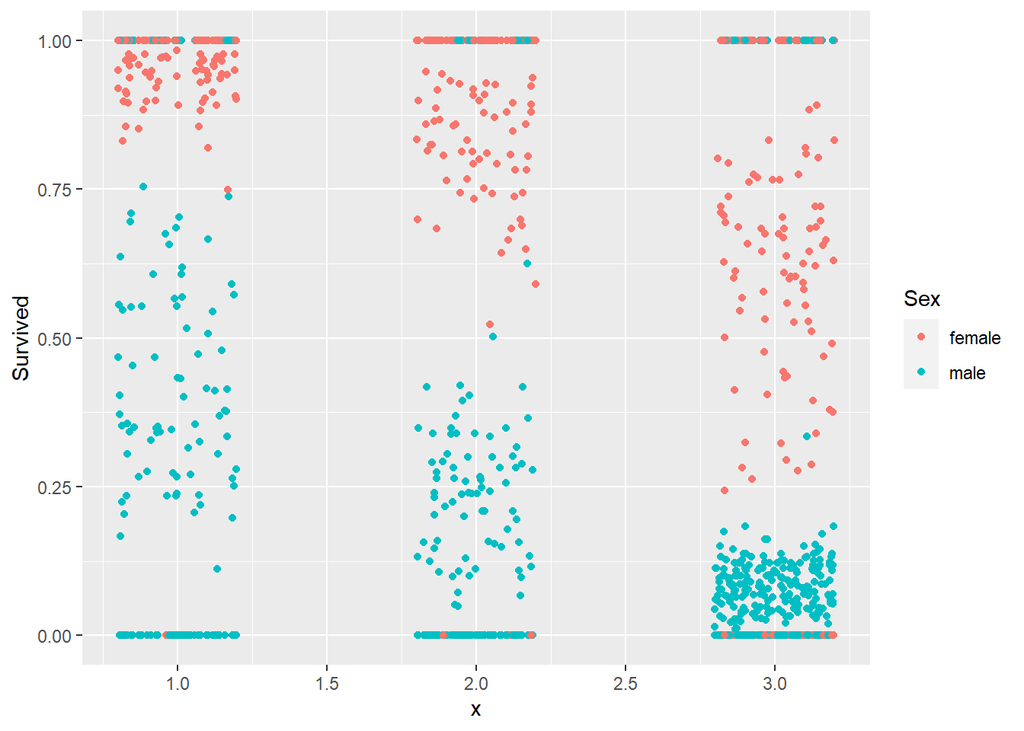

```r
library(ggplot2)
df<-titanic_mytrain[,c(2,5)]
df$x<-x
ggplot(df,aes(x=x,y=Survived,col=Sex))+geom_point()+
  geom_point(aes(x=x,y=titanicmod1$fitted.values,col=Sex))
```

2. (2pts) Create a logistic model with interactions.

```r
titanicmod2<-glm(Survived ~ Pclass * Sex + Age + SibSp + Parch + Fare + Embarked,
                   data = titanic_mytrain,
                   family = "binomial")

summary(titanicmod2)
```

```
##
## Call:
## glm(formula = Survived ~ Pclass * Sex + Age + SibSp + Parch +
##     Fare + Embarked, family = "binomial", data = titanic_mytrain)
##
## Coefficients:
##                  Estimate Std. Error z value Pr(>|z|)
## (Intercept)     19.978079 607.714749   0.033 0.973775
## Pclass          -2.640753   0.437895  -6.031 1.63e-09 ***
## Sexmale         -6.799641   1.154750  -5.888 3.90e-09 ***
## Age             -0.046143   0.009772  -4.722 2.33e-06 ***
## SibSp           -0.360349   0.154424  -2.334 0.019621 *
## Parch            0.022900   0.152056   0.151 0.880287
## Fare            -0.004645   0.005134  -0.905 0.365611
## EmbarkedC      -10.212718 607.714427  -0.017 0.986592
## EmbarkedQ      -10.837871 607.714659  -0.018 0.985771
## EmbarkedS      -10.843780 607.714375  -0.018 0.985764
## Pclass:Sexmale   1.609252   0.430808   3.735 0.000187 ***
## ---
## Signif. codes:  0 '***' 0.001 '**' 0.01 '*' 0.05 '.' 0.1 ' ' 1
##
## (Dispersion parameter for binomial family taken to be 1)
##
##     Null deviance: 769.86  on 570  degrees of freedom
## Residual deviance: 462.28  on 560  degrees of freedom
## AIC: 484.28
##
## Number of Fisher Scoring iterations: 13
```

b2) (1pts) Do backwards selection, use trace = 0

```r
titanicmod3<-step(titanicmod2, direction = "backward", trace = 0)
summary(titanicmod3)
```

```
##
## Call:
## glm(formula = Survived ~ Pclass + Sex + Age + SibSp + Pclass:Sex,
##     family = "binomial", data = titanic_mytrain)
##
## Coefficients:
##                 Estimate Std. Error z value Pr(>|z|)
## (Intercept)     8.879950   1.200533   7.397 1.40e-13 ***
## Pclass         -2.533710   0.400352  -6.329 2.47e-10 ***
## Sexmale        -6.589890   1.136142  -5.800 6.62e-09 ***
## Age            -0.046168   0.009708  -4.756 1.98e-06 ***
## SibSp          -0.393931   0.144457  -2.727 0.006392 **
## Pclass:Sexmale  1.533478   0.422660   3.628 0.000285 ***
## ---
## Signif. codes:  0 '***' 0.001 '**' 0.01 '*' 0.05 '.' 0.1 ' ' 1
##
## (Dispersion parameter for binomial family taken to be 1)
##
##     Null deviance: 769.86  on 570  degrees of freedom
## Residual deviance: 466.70  on 565  degrees of freedom
## AIC: 478.7
##
## Number of Fisher Scoring iterations: 6
```

b3) (4pts) Interpret all interaction terms coefficients.

Pclass:Sex (Interaction):

Estimate: 1.533478 Interpretation: This represents the additional change in the log-odds of survival for the interaction effect between Pclass and Sex. It shows how the effect of Pclass on the log-odds of survival differs between the levels of Sex.

3. (3pts) Compare titanicmod1,titanicmod3 (using anova)

```r
anova_output<-anova(titanicmod1, titanicmod3, test = "Chi")
print(anova_output)
```

```
## Analysis of Deviance Table
##
## Model 1: Survived ~ Pclass + Sex + Age + SibSp + Parch + Fare + Embarked
## Model 2: Survived ~ Pclass + Sex + Age + SibSp + Pclass:Sex
##   Resid. Df Resid. Dev Df Deviance Pr(>Chi)
## 1       561     480.25
## 2       565     466.70 -4   13.551
```

Write the null and alternative hypothesis corresponding to this test:

4. (1pt) Plot the assessment plots for titanicmod3

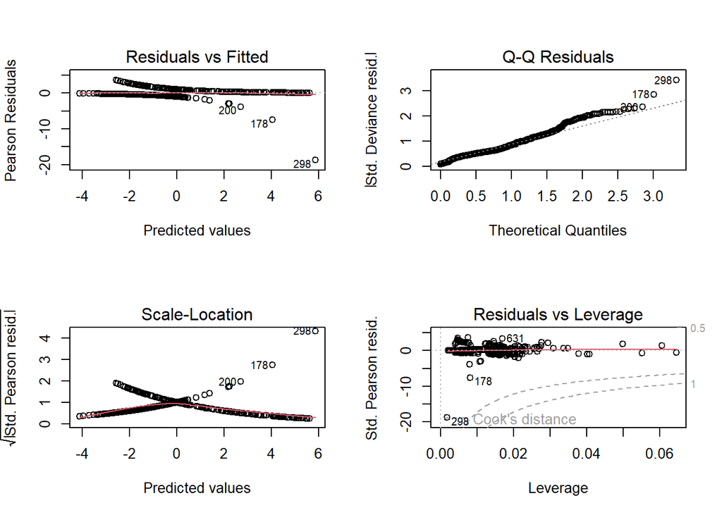

```r
par(mfrow=c(2,2))  # Setting up a 2x2 layout for the plots
plot(titanicmod3)
```

### Confusion matrix and statistics

5. (1pt) Compute the confusion matrix for both models on the testing data.

```r
library(caret)
# for first model
fit_test<-predict(titanicmod1,newdata=titanic_mytest[,-2],type="response")
cm1<-confusionMatrix(data=as.factor((fit_test>.5)*1), reference=as.factor(titanic_mytest$Survived))
cm1$table
```

```
##           Reference
## Prediction  0  1
##          0 69 23
##          1 14 37
```

```r
# for second model
fit_test<-predict(titanicmod3, newdata = titanic_mytest[,-2], type = "response")
cm3 <- confusionMatrix(data = as.factor((fit_test > 0.5) * 1), reference = as.factor(titanic_mytest$Survived))
cm3$table
```

```
##           Reference
## Prediction  0  1
##          0 75 24
##          1  8 36
```

Which of the two models performs better?

accuracy for titanicmod1 model=(69+37)/(69+23+14+37)= 0.74 accuracy for titanicmod3 model=(75+36)/(75+24+8+36)= 0.77 The model with a higher accuracy is considered better. Hence model “titanicmod3” is better model than model “titanicmod1”

6. (2pt) Compute the auc for both models

```r
library(Epi)
# titanic1
library(pROC)
# For model 1
roc1 <- roc(titanic_mytest$Survived, predict(titanicmod1, newdata = titanic_mytest[,-2]))
# Display AUC values
paste("AUC for Model 1:", round(auc(roc1), 4))
```

```
## [1] "AUC for Model 1: 0.7944"
```

```r
# For model 3
roc3 <- roc(titanic_mytest$Survived, predict(titanicmod3, newdata = titanic_mytest[,-2]))
paste("AUC for Model 3:", round(auc(roc3), 4))
```

```
## [1] "AUC for Model 3: 0.8024"
```

```r
#titanic3
```

AUC for titanic1:0.7944

AUC for titanic3: 0.8024

7. (2pts) Write a short comment comparing the two models.

Model 1 has an AUC of 0.7944. Model 3 has a slightly higher AUC of 0.8024. A higher AUC generally indicates better discrimination. Therefore, based on the AUC values: Model 3 performs slightly better in terms of discriminatory power compared to Model 1.

# 3. Breast Cancer

(40 pts) Variables: * age and agegp, * menopause, * tsize and tumorsize” * invnodes2 and inv.nodes * node.caps * deg.malig: severity of malignity  
* breast (left/right) and breastquad (L/R and up/central/low) * irradiate * Class and Y.

We will use Y as the response variable

```r
breast <- read.csv("C:/Users/vinay/OneDrive/Documents/Applied Stats/Assignment 6/breast.csv")

str(breast)
```

```
## 'data.frame':    286 obs. of  14 variables:
##  $ age       : int  45 55 55 45 45 55 55 45 45 45 ...
##  $ agegp     : chr  "40-49" "50-59" "50-59" "40-49" ...
##  $ menopause : chr  "premeno" "ge40" "ge40" "premeno" ...
##  $ tsize     : int  17 17 37 37 32 27 42 12 2 42 ...
##  $ tumorsize : chr  "15-19" "15-19" "35-39" "35-39" ...
##  $ invnodes2 : int  1 1 1 1 4 4 1 1 1 16 ...
##  $ inv.nodes : chr  "0-2" "0-2" "0-2" "0-2" ...
##  $ node.caps : chr  "yes" "no" "no" "yes" ...
##  $ deg.malig : int  3 1 2 3 2 2 3 2 2 2 ...
##  $ breast    : chr  "right" "right" "left" "right" ...
##  $ breastquad: chr  "left_up" "central" "left_low" "left_low" ...
##  $ irradiate : chr  "no" "no" "no" "yes" ...
##  $ Class     : chr  "recurrence-events" "no-recurrence-events" "recurrence-events" "no-recurrence-events" ...
##  $ Y         : int  1 0 1 0 1 0 0 0 0 0 ...
```

Missing data have been coded with ?. Change it ti NA and then remove the NA’s.

```r
breast[breast == "?"] <- NA  # Replace "?" with NA
# Remove rows with NA values
newbreast <-na.omit(breast )  # removes all rows with missing data NA
```

1. (2pt) Develop a logistic model with tsize and deg.malig

```r
logmod<-glm(Y ~ tsize + deg.malig, data = newbreast, family = "binomial")
summary(logmod)
```

```
##
## Call:
## glm(formula = Y ~ tsize + deg.malig, family = "binomial", data = newbreast)
##
## Coefficients:
##             Estimate Std. Error z value Pr(>|z|)
## (Intercept) -3.99098    0.61564  -6.483 9.01e-11 ***
## tsize        0.03080    0.01407   2.189   0.0286 *
## deg.malig    1.03937    0.21402   4.856 1.20e-06 ***
## ---
## Signif. codes:  0 '***' 0.001 '**' 0.01 '*' 0.05 '.' 0.1 ' ' 1
##
## (Dispersion parameter for binomial family taken to be 1)
##
##     Null deviance: 334.78  on 276  degrees of freedom
## Residual deviance: 297.96  on 274  degrees of freedom
## AIC: 303.96
##
## Number of Fisher Scoring iterations: 4
```

2. (4pts) Develop a logistic model with all variables. Use age but not agegp, tsize but not tumorsize, and invnodes2 but not inv.nodes.

```r
logmod2<-glm(Y ~ age + menopause + tsize + invnodes2 + node.caps + deg.malig + breast + breastquad + irradiate,
               data = newbreast,
               family = "binomial")
summary(logmod2)
```

```
##
## Call:
## glm(formula = Y ~ age + menopause + tsize + invnodes2 + node.caps +
##     deg.malig + breast + breastquad + irradiate, family = "binomial",
##     data = newbreast)
##
## Coefficients:
##                       Estimate Std. Error z value Pr(>|z|)
## (Intercept)           -3.11393    1.49449  -2.084 0.037196 *
## age                   -0.01430    0.02067  -0.692 0.489100
## menopauselt40        -15.13643 1031.38329  -0.015 0.988291
## menopausepremeno       0.14789    0.42084   0.351 0.725276
## tsize                  0.02179    0.01526   1.428 0.153357
## invnodes2              0.04757    0.04177   1.139 0.254822
## node.capsyes           0.49779    0.39812   1.250 0.211167
## deg.malig              0.85750    0.23832   3.598 0.000321 ***
## breastright           -0.20804    0.32133  -0.647 0.517348
## breastquadleft_low     0.20002    0.65218   0.307 0.759070
## breastquadleft_up     -0.01243    0.66507  -0.019 0.985092
## breastquadright_low   -0.20204    0.84091  -0.240 0.810129
## breastquadright_up     0.60336    0.73885   0.817 0.414144
## irradiateyes           0.50774    0.34536   1.470 0.141510
## ---
## Signif. codes:  0 '***' 0.001 '**' 0.01 '*' 0.05 '.' 0.1 ' ' 1
##
## (Dispersion parameter for binomial family taken to be 1)
##
##     Null deviance: 334.78  on 276  degrees of freedom
## Residual deviance: 279.24  on 263  degrees of freedom
## AIC: 307.24
##
## Number of Fisher Scoring iterations: 15
```

3. (1pt) Use backwards selection to clean the model.

```r
logmod3<-step(logmod2, direction = "backward")
```

```
## Start:  AIC=307.24
## Y ~ age + menopause + tsize + invnodes2 + node.caps + deg.malig +
##     breast + breastquad + irradiate
##
##              Df Deviance    AIC
## - breastquad  4   281.34 301.34
## - breast      1   279.66 305.66
## - menopause   2   281.70 305.70
## - age         1   279.72 305.72
## - invnodes2   1   280.63 306.63
## - node.caps   1   280.77 306.77
## <none>            279.24 307.24
## - tsize       1   281.28 307.28
## - irradiate   1   281.36 307.36
## - deg.malig   1   293.15 319.15
##
## Step:  AIC=301.34
## Y ~ age + menopause + tsize + invnodes2 + node.caps + deg.malig +
##     breast + irradiate
##
##             Df Deviance    AIC
## - age        1   281.69 299.69
## - breast     1   281.69 299.69
## - menopause  2   284.05 300.05
## - invnodes2  1   282.48 300.48
## - irradiate  1   283.10 301.10
## - node.caps  1   283.18 301.18
## <none>           281.34 301.34
## - tsize      1   284.28 302.28
## - deg.malig  1   295.59 313.59
##
## Step:  AIC=299.69
## Y ~ menopause + tsize + invnodes2 + node.caps + deg.malig + breast +
##     irradiate
##
##             Df Deviance    AIC
## - breast     1   282.09 298.09
## - invnodes2  1   282.98 298.98
## - node.caps  1   283.45 299.45
## - irradiate  1   283.48 299.48
```

[output cut: 12 more lines]

```
## <none>           282.09 298.09
## - menopause  2   286.15 298.15
## - tsize      1   284.81 298.81
## - deg.malig  1   297.25 311.25
##
## Step:  AIC=297.38
## Y ~ menopause + tsize + node.caps + deg.malig + irradiate
##
##             Df Deviance    AIC
## <none>           283.38 297.38
## - menopause  2   287.49 297.49
## - irradiate  1   285.62 297.62
## - tsize      1   286.05 298.05
## - node.caps  1   287.82 299.82
## - deg.malig  1   300.87 312.87
```

```r
summary(logmod3)
```

```
##
## Call:
## glm(formula = Y ~ menopause + tsize + node.caps + deg.malig +
##     irradiate, family = "binomial", data = newbreast)
##
## Coefficients:
##                   Estimate Std. Error z value Pr(>|z|)
## (Intercept)       -4.06335    0.69482  -5.848 4.97e-09 ***
## menopauselt40    -15.09420  992.24518  -0.015   0.9879
## menopausepremeno   0.36792    0.29887   1.231   0.2183
## tsize              0.02387    0.01468   1.626   0.1041
## node.capsyes       0.73576    0.34819   2.113   0.0346 *
## deg.malig          0.93116    0.23266   4.002 6.27e-05 ***
## irradiateyes       0.50555    0.33547   1.507   0.1318
## ---
## Signif. codes:  0 '***' 0.001 '**' 0.01 '*' 0.05 '.' 0.1 ' ' 1
##
## (Dispersion parameter for binomial family taken to be 1)
##
##     Null deviance: 334.78  on 276  degrees of freedom
## Residual deviance: 283.38  on 270  degrees of freedom
## AIC: 297.38
##
## Number of Fisher Scoring iterations: 15
```

4. (4pts) Compare the models using anova.

```r
# Fit the models
logmod <- glm(Y ~ tsize + deg.malig, data = newbreast, family = "binomial")
logmod_all <- glm(Y ~ age + menopause + tsize + invnodes2 + node.caps + deg.malig + breast + breastquad + irradiate,
                  data = newbreast, family = "binomial")
logmod3 <- glm(Y ~ menopause + tsize + node.caps + deg.malig + irradiate, data = newbreast, family = "binomial")

# Perform ANOVA
anova_result <- anova(logmod, logmod_all, logmod3, test = "Chisq")
print(anova_result)
```

```
## Analysis of Deviance Table
##
## Model 1: Y ~ tsize + deg.malig
## Model 2: Y ~ age + menopause + tsize + invnodes2 + node.caps + deg.malig +
##     breast + breastquad + irradiate
## Model 3: Y ~ menopause + tsize + node.caps + deg.malig + irradiate
##   Resid. Df Resid. Dev Df Deviance Pr(>Chi)
## 1       274     297.96
## 2       263     279.24 11  18.7281  0.06615 .
## 3       270     283.38 -7  -4.1439  0.76307
## ---
## Signif. codes:  0 '***' 0.001 '**' 0.01 '*' 0.05 '.' 0.1 ' ' 1
```

Write the null and alternative hypothesis corresponding to this test: Null hypothesis: The models (Model 1 and Model 2, as well as Model 1 and Model 3) are equivalent, and the additional predictors in the more complex models (Model 2 and Model 3) do not significantly contribute to explaining the variability in the response variable Y.

Alternative hypothesis: There is a significant difference in deviance between the simpler model (Model 1) and the more complex models (Model 2 and Model 3), indicating that the additional predictors in the complex models contribute significantly to explaining the variability in the response variable Y.

5. (4pts) Plot the fitted values of logmod3 over a plot of Y vs tsize. Color according to deg.malig. Add a horizontal line at y=.25. If using ggplot: geom_hline(yintercept = .22,col=“grey”)

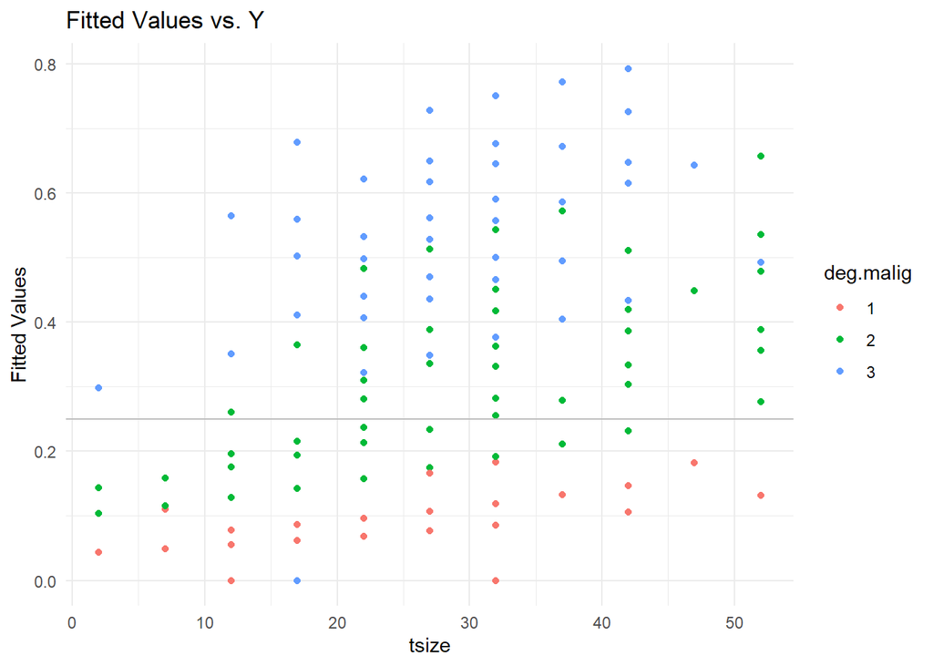

```r
library(ggplot2)

# Plotting the fitted values
plot_data <- data.frame(tsize = newbreast$tsize, fitted_values = predict(logmod3, type = "response"))
plot_data$deg.malig <- as.factor(newbreast$deg.malig)

ggplot(plot_data, aes(x = tsize, y = fitted_values, color = deg.malig)) +
  geom_point() +
  geom_hline(yintercept = 0.25, col = "grey") +
  labs(title = "Fitted Values vs. Y",
       x = "tsize",
       y = "Fitted Values") +
  theme_minimal()
```

6. (4pts) Use the variables in the logmod3 but now add a polynomial of degree 2 on tsize and deg.malig.

```r
# Create a new variable for the squared term of tsize
newbreast$tsize_sq <- newbreast$tsize^2

# Create a new variable for the squared term of deg.malig
newbreast$deg_malig_sq <- newbreast$deg.malig^2

# Logistic model with polynomial terms
logmod4 <- glm(Y ~ menopause + tsize + tsize_sq + node.caps + deg.malig + deg_malig_sq + irradiate,
               family = "binomial",
               data = newbreast)

# Display the summary
summary(logmod4)
```

```
##
## Call:
## glm(formula = Y ~ menopause + tsize + tsize_sq + node.caps +
##     deg.malig + deg_malig_sq + irradiate, family = "binomial",
##     data = newbreast)
##
## Coefficients:
##                    Estimate Std. Error z value Pr(>|z|)
## (Intercept)       -2.790766   1.641202  -1.700   0.0890 .
## menopauselt40    -15.207305 984.111346  -0.015   0.9877
## menopausepremeno   0.407365   0.307931   1.323   0.1859
## tsize              0.124795   0.070186   1.778   0.0754 .
## tsize_sq          -0.001733   0.001161  -1.492   0.1357
## node.capsyes       0.769094   0.359369   2.140   0.0323 *
## deg.malig         -1.752482   1.361765  -1.287   0.1981
## deg_malig_sq       0.616284   0.319057   1.932   0.0534 .
## irradiateyes       0.579789   0.345523   1.678   0.0933 .
## ---
## Signif. codes:  0 '***' 0.001 '**' 0.01 '*' 0.05 '.' 0.1 ' ' 1
##
## (Dispersion parameter for binomial family taken to be 1)
##
##     Null deviance: 334.78  on 276  degrees of freedom
## Residual deviance: 276.86  on 268  degrees of freedom
## AIC: 294.86
##
## Number of Fisher Scoring iterations: 15
```

7. (4pts) Compare logmod3 and logmod4 using anova

```r
# Compare logmod3 and logmod4 using ANOVA
anova_result <- anova(logmod3, logmod4, test = "Chi")

# Display the result
print(anova_result)
```

```
## Analysis of Deviance Table
##
## Model 1: Y ~ menopause + tsize + node.caps + deg.malig + irradiate
## Model 2: Y ~ menopause + tsize + tsize_sq + node.caps + deg.malig + deg_malig_sq +
##     irradiate
##   Resid. Df Resid. Dev Df Deviance Pr(>Chi)
## 1       270     283.38
## 2       268     276.86  2   6.5193   0.0384 *
## ---
## Signif. codes:  0 '***' 0.001 '**' 0.01 '*' 0.05 '.' 0.1 ' ' 1
```

Which model is preffered?

– The results indicate that Model 2 with the polynomial terms ($\text{tsize\_sq}$ and $\text{deg\_malig\_sq}$) has a lower residual deviance compared to Model 1, and the difference in deviance is statistically significant ($Pr(>\chi) = 0.0384$). This suggests that Model 2 is preferred over Model 1. In conclusion, the addition of the polynomial terms improves the model fit, and Model 2 is preferred for predicting.

8. (1pt) Plot the assessment plots for logmod4

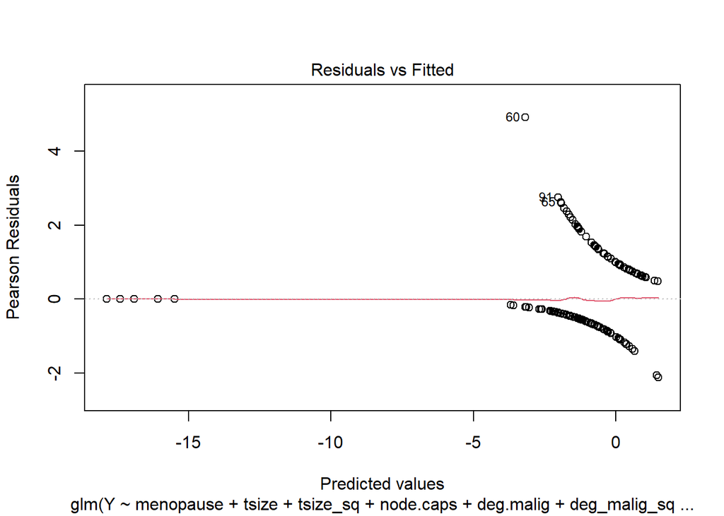

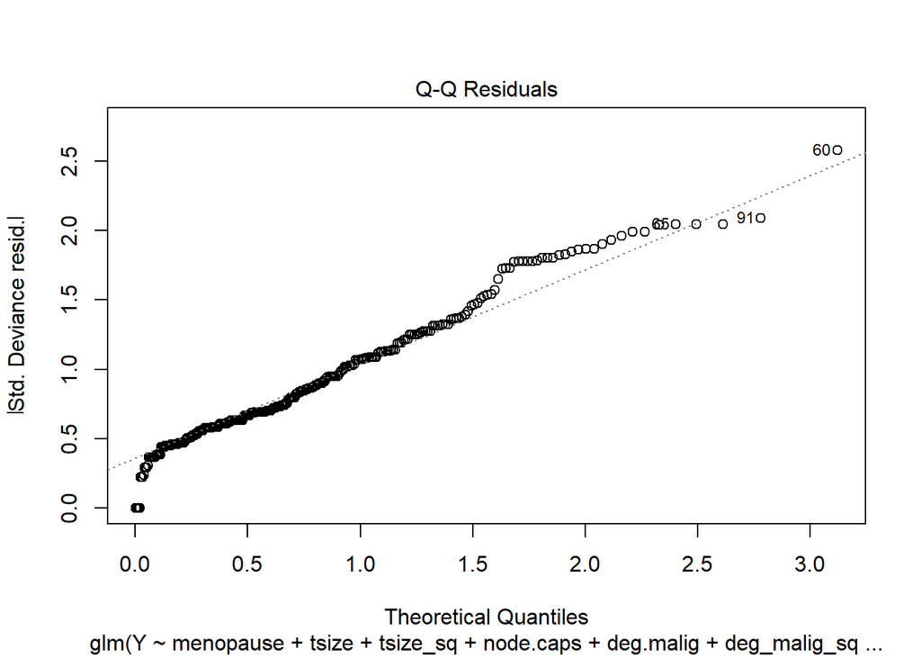

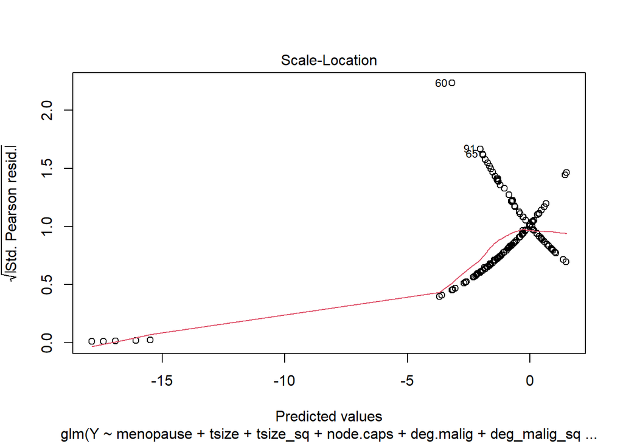

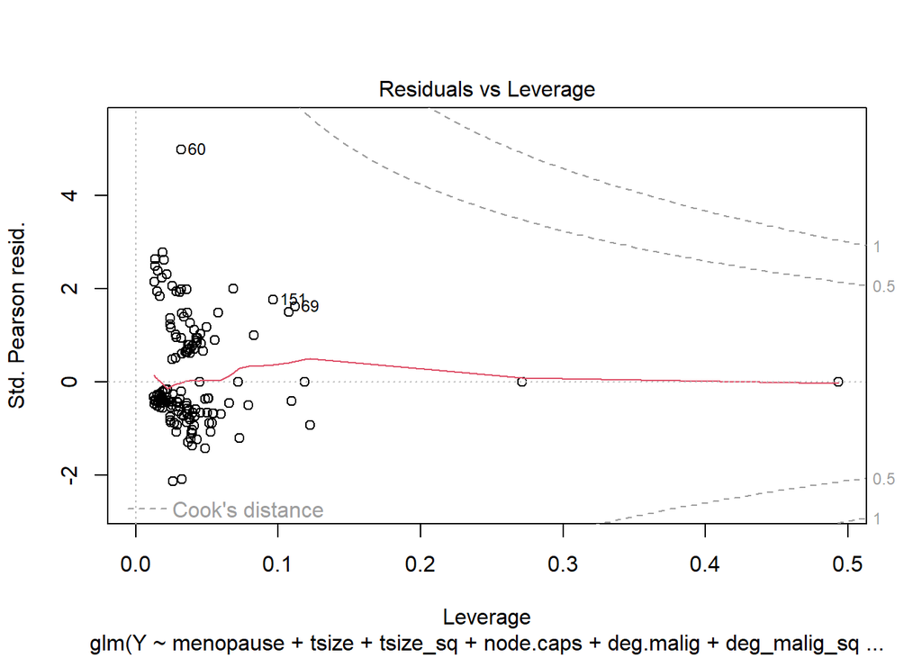

```r
# Plot assessment plots for logmod4
plot(logmod4, which = c(1, 2, 3, 5))
```

1. (4pts) Plot the fitted values over a plot of Y vs tsize. Color according to deg.malig. Add a horizontal line at y=.25. If using ggplot: geom_hline(yintercept = .25,col=“grey”)

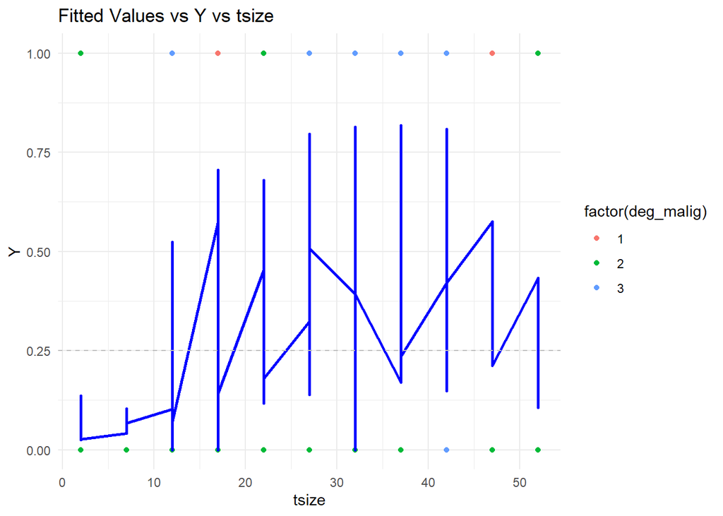

```r
# Predicted values from logmod4
predicted_probs <- predict(logmod4, type = "response")

# Create a data frame for plotting
plot_data <- data.frame(Y = newbreast$Y, tsize = newbreast$tsize, deg_malig = newbreast$deg.malig, Predicted = predicted_probs)

# Plot the fitted values over Y vs tsize
library(ggplot2)
ggplot(plot_data, aes(x = tsize, y = Y, color = factor(deg_malig))) +
  geom_point() +
  geom_line(aes(y = Predicted), color = "blue", size = 1) +
  geom_hline(yintercept = 0.25, linetype = "dashed", color = "grey") +
  labs(title = "Fitted Values vs Y vs tsize",
       x = "tsize",
       y = "Y") +
  theme_minimal()
```

10. (6pts) Use Epi::ROC to plot the ROC curve and select a threshold for logmod3 and logmod4. Compute the auc for both models. Note: instead of poly(tsize,2) use tsize +I(tsize^2), and do the same for deg.malig.

auc for logmod3: Suggested threshold:

auc for logmod4: Suggested threshold:

Which model is better?

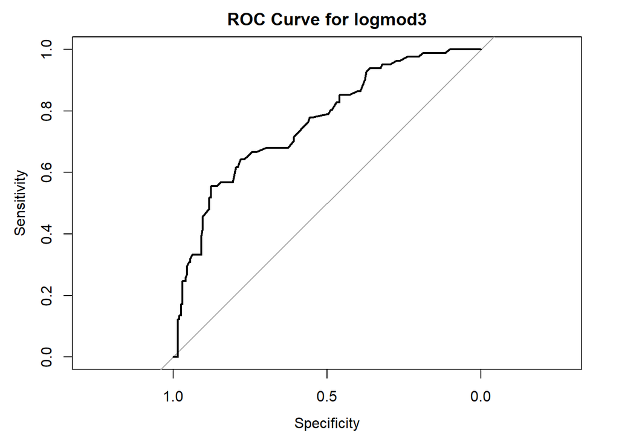

```r
# Load the Epi package
library(Epi)

# Create a new variable for the squared term of tsize and deg.malig
newbreast$tsize_sq <- newbreast$tsize^2
newbreast$deg_malig_sq <- newbreast$deg.malig^2

# Logistic model with polynomial terms for logmod3
logmod3 <- glm(Y ~ menopause + tsize + node.caps + deg.malig + irradiate,
               family = "binomial",
               data = newbreast)

# Logistic model with polynomial terms for logmod4
logmod4 <- glm(Y ~ menopause + tsize + tsize_sq + node.caps + deg.malig + deg_malig_sq +
                 irradiate,
               family = "binomial",
               data = newbreast)

# ROC curve for logmod3
roc_mod3 <- roc(newbreast$Y, predict(logmod3, type = "response"))
plot(roc_mod3, main = "ROC Curve for logmod3")
```

```r
auc_mod3 <- auc(roc_mod3)
suggested_threshold_mod3 <- coords(roc_mod3, "best")$threshold
cat("AUC for logmod3:", auc_mod3, "\nSuggested threshold:", suggested_threshold_mod3, "\n")
```

```
## AUC for logmod3: 0.7616213
## Suggested threshold: 0.4347756
```

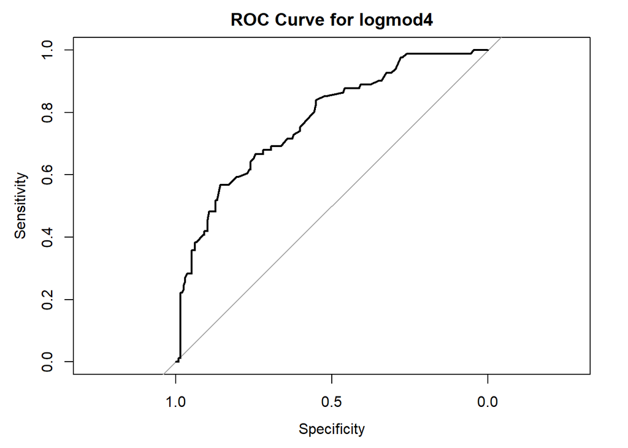

```r
# ROC curve for logmod4
roc_mod4 <- roc(newbreast$Y, predict(logmod4, type = "response"))
plot(roc_mod4, main = "ROC Curve for logmod4")
```

```r
auc_mod4 <- auc(roc_mod4)
suggested_threshold_mod4 <- coords(roc_mod4, "best")$threshold
cat("AUC for logmod4:", auc_mod4, "\nSuggested threshold:", suggested_threshold_mod4, "\n")
```

```
## AUC for logmod4: 0.7732741
## Suggested threshold: 0.4280508
```

```r
# Compare the models
if (auc_mod3 > auc_mod4) {
  cat("Model logmod3 is better.\n")
} else if (auc_mod3 < auc_mod4) {
  cat("Model logmod4 is better.\n")
} else {
  cat("Both models are equal.\n")
}
```

```
## Model logmod4 is better.
```

The model with a higher AUC is generally considered better for classification purposes. The suggested threshold is the one that maximizes sensitivity plus specificity on the ROC curve. It’s crucial to interpret the AUC along with the context of your specific problem and requirements.

11. (4pts) Compute the confusion matrix using logmod3 and logmod4 and a threshold of .25

confusion matrix using logmod3:

confusion matrix using logmod4:

Which model is better?

```r
library(caret)

# Predictions using logmod3 and logmod4 with threshold 0.25
fit_logmod3 <- predict(logmod3, newdata = newbreast, type = "response")
fit_logmod4 <- predict(logmod4, newdata = newbreast, type = "response")

# Convert probabilities to binary predictions using threshold 0.25
pred_logmod3 <- ifelse(fit_logmod3 > 0.25, 1, 0)
pred_logmod4 <- ifelse(fit_logmod4 > 0.25, 1, 0)

# True outcomes
actual <- newbreast$Y

# Confusion matrix for logmod3
cm_logmod3 <- confusionMatrix(data = as.factor(pred_logmod3), reference = as.factor(actual))
print("Confusion matrix using logmod3:")
```

```
## [1] "Confusion matrix using logmod3:"
```

```r
print(cm_logmod3$table)
```

```
##           Reference
## Prediction   0   1
##          0 119  24
##          1  77  57
```

```r
# Confusion matrix for logmod4
cm_logmod4 <- confusionMatrix(data = as.factor(pred_logmod4), reference = as.factor(actual))
print("Confusion matrix using logmod4:")
```

```
## [1] "Confusion matrix using logmod4:"
```

```r
print(cm_logmod4$table)
```

```
##           Reference
## Prediction   0   1
##          0 135  25
##          1  61  56
```

12. (2pt) Write a brief comment on the two models.

Both logmod3 and logmod4 are logistic regression models built to predict the binary outcome variable Y.

1. **logmod3:**
   - Utilizes menopause, tsize, node.caps, deg.malig, and irradiate as predictor variables.
   - The model includes linear terms for tsize and deg.malig.
   - Achieved an AUC of approximately 0.762.
2. **logmod4:**
   - Similar to logmod3 but introduces polynomial terms for tsize and deg.malig, including quadratic terms (tsize_sq and deg_malig_sq).
   - Achieved a slightly higher AUC of approximately 0.773.

**Comparison:** - The introduction of polynomial terms in logmod4 allows the model to capture potential non-linear relationships between tsize, deg.malig, and the log-odds of the response variable. - Despite the slight improvement in AUC, the choice between logmod3 and logmod4 depends on factors such as interpretability, computational complexity, and the specific goals of the analysis. - Logmod4 may be preferred when there is evidence of non-linear relationships in the data, but it also comes with the cost of increased complexity. The decision should be made based on a balance between model performance and interpretability.